# Project Report for Practical Marchine Learning

## Problem discription

Different manners of excercise lead to different training results. This study targets to build a prediction model to predict the training classes of performing barbell lifts correctly and incorrectly based on the reading from the accelerometers on the belt, forearm, arm, and dumbell . The original data for this study can be fount at http://groupware.les.inf.puc-rio.br/har.

## Choice of machine learning algorithm

Since the training classes are divided into 5 different categories, it is a multi-level classification problem. Methods like logistical regression, support vector machines are suitable for 1 and 0 classifications. Hence, to perform multi-level classification, algorithms like decision tree should be used. However, the decision tree is prone to overfitting, and the trade of between bias and variance could be difficult when using decision tree. Thus, to overcome the overfitting problem, bootstrap aggregation, normally called bagging needs to be used. By using decision tree with bagging, it leads to a new algorithm called random forest. Hence, in this project, random forest is chosen as the machine learning algorithm for this multi-level prediction problems. Random forest also uses the out-of-bag (oob) error to estimate the prediction error, and thus, in this project, to pass the 20 testing cases, the prediction error should be < 5%. The algorithm of random forest is written as below.

```
RandomForest(D)
for n = 1:N
   (1) bootstrapping with the full set D to obtain the subset Dt.
   (2) training the decision trees on the subset Dt to obtain the hypothesis of the decision tree as gt.
return random forest hypothesis RF = uniform voting of gt
```

## Choice of predictors

Common sense or domain knowledge could be served as the initial pass of choosing predictors. For more detailed choice, permutation of each predictor should be applied to determine whether that particular predictor is signficant or not. However, this really requires huge computation sources considering the total number of the predictors. Thus, limited by the computation power available in this project, the choice of the predictors are primarily based on the following two criteria: – The availability of the data: Many columns has data as NA, and thus are poor predictors that could be eliminated the the first pass. – Common sense are used: For example, the accelerometers on the belts are definitely needed, that are the column with “roll_belt”, “pitch_belt”, “yaw_belt”. Also, the “total_accel_belt” do not need to be included because it is the summation of “roll_belt”, “pitch_belt”, “yaw_belt”, which means that “total_accel_belt” is not an indpendent variable.

Hence, after reading in the training data, the final choice of the predictors can summarized by the following R codes.

```
pml_training_raw<-read.csv("pml-training.csv")
selectedCol <- c(grep("raw_timestamp", names(pml_training_raw)),
         which(names(pml_training_raw) == "roll_belt"),
                 which(names(pml_training_raw) == "pitch_belt"),
                 which(names(pml_training_raw) == "yaw_belt"),
                 grep("gyros_", names(pml_training_raw)),
                 grep("magnet_", names(pml_training_raw)),
                 which(names(pml_training_raw) == "roll_arm"),
                 which(names(pml_training_raw) == "pitch_arm"),
                 which(names(pml_training_raw) == "yaw_arm"),
                 which(names(pml_training_raw) == "roll_dumbbell"),
                 which(names(pml_training_raw) == "pitch_dumbbell"),
                 which(names(pml_training_raw) == "yaw_dumbbell"),
                 which(names(pml_training_raw) == "classe")

         )
```

## Training Results

The training of random forest can be done through the following code by using the default settings, where “rf” stands for random forest method is used in training.

```
pml_training <- pml_training_raw[,selectedCol]
train_predictors <- pml_training[, -which(names(pml_training) == "classe")]
modelFit<-train(pml_training$classe ~ ., method="rf", data=train_predictors)
```

The training results can be summarized as the following with the OOB estimation as

```
 randomForest(x = x, y = y, mtry = param$mtry)
               Type of random forest: classification
                     Number of trees: 500
No. of variables tried at each split: 2

        OOB estimate of  error rate: 1.68%
Confusion matrix:
     A    B    C    D    E class.error
A 5554    8   10    6    2 0.004659498
B   56 3700   34    3    4 0.025546484
C    5   29 3360   21    7 0.018118060
D    6    4   92 3108    6 0.033582090
E    2    9   16   10 3570 0.010257832
```

It shows OOB erorr of 1.68%, which is below 5%, and it is easy to confirm that all the 20 test cases can be passed with this model.

[figure not shown]

```r
plot(modelFit$final)
```

[output not shown]

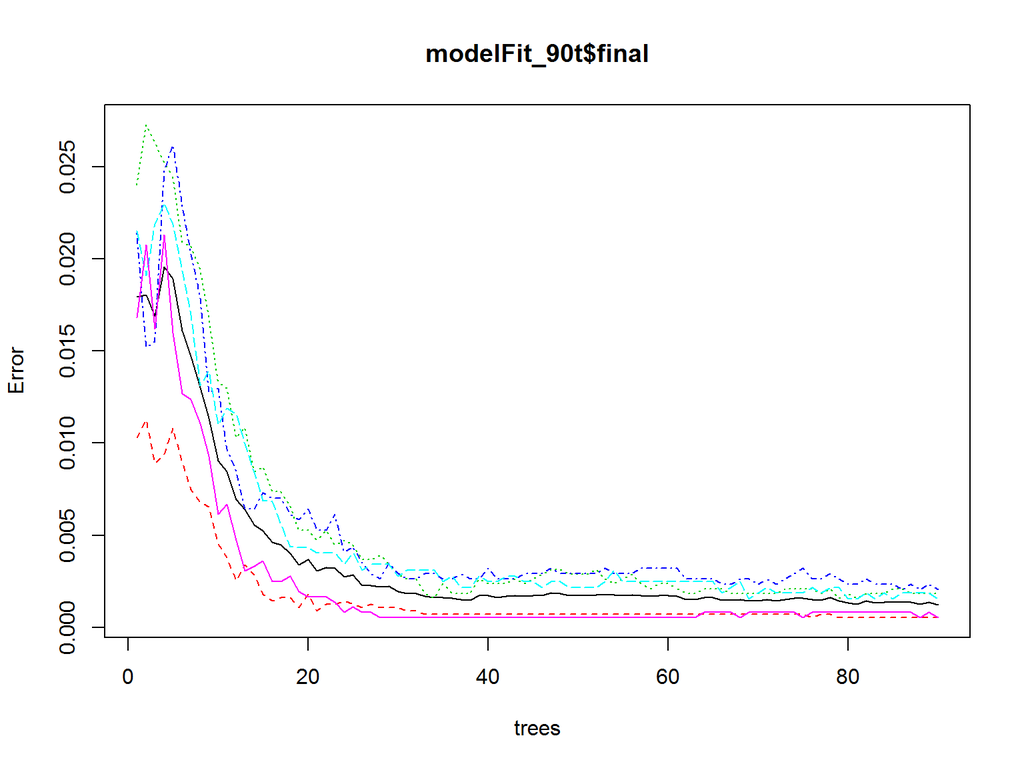

```r
plot(modelFit_90t$final)
```